# TRABALHO DE STEVEN DE BIBLIO

ANSELMO

19/09/2021

# INTRODUÇÃO

Volumosos gastos militares sempre fizeram parte do orçamento de diversos Estados, sejam eles democrátios ou não. Independentemente de seus múltiplos aspectos, a perspectiva Realista em Relações Internacionais tem como característica teórica mostrar que o sistema internacional é movido segundo a lógica do poder, da força. Neste sentido, a paz mundial é administrada pelos ditames do mais forte. Sendo assim, o Realismo ganha relevância, na medida em que, as questões de segurança internacional estão sempre associadas aos gastos militares, pois é através dele que se podem custear homens e insumos bélicos para a exibição de força. Apesar do que pode parecer, por conta do dilema de segurança, não se trata da ideia de um estado de guerra contínuo, mas de estar pronto para a guerra e ser forte o suficiente para defender o Estado. Quanto maior o gasto militar, mais protegido e autônomo um Estado se tornará. Eis a perspectiva Realista em Relações Internacionais.

# 1 MARCO TEÓRICO

“Em um mundo onde os poderosos fazem o que tem que fazer e os fracos aceitam o que tem que aceitar.”

Baseada nas concepções realistas de Tucídides, esta frase exemplifica de forma elucidativa um dos grandes paradigmas das RI, o Realismo. Presente até hoje em países de importância mundial, é uma teoria que possui uma visão Estado-cêntrica, caracterizada pela falta de interesse no que acontece no sistema nacional, uma vez que o Realismo enxerga os Estados como caixas pretas, onde o que acontece dentro deles não tem relevância. Os realistas ainda destacam elementos que representam as premissas centrais, resumindo de certa forma o pensamento realista, e são elas: a sobrevivência, poder, anarquia e auto-ajuda, e elas nos guiarão para o entendimento dessa teoria. Na visão dos realistas, o Estado é o ator central das relações internacionais. Tem como função a estabilidade doméstica e a segurança em relação às ações externas, caracteriza-se pelo uso legítimo da força e é visto como unitário e racional, agindo de maneira uniforme e homogênia em defesa do interesse internacional. A anarquia é entendida como a ausência de uma autoridade suprema, visto que os realistas consideram a inexistência de um único soberano internacional que tenha monopólio do uso legítimo da força, e o que existe é a coexistência de soberanos. Nela, os Estados lutam por sobrevivência e desconfiam um dos outros. Resultante de um estado de anarquia, a sobrevivência - juntamente com poder e auto ajuda - é de interesse nacional e visa a permanência do Estado como ator.

Para os realistas, a segurança do indivíduo só é mantida se o Estado estiver seguro e que qualquer outro objetivo do governante não pode diminuir ou se opor ao objetivo primordial da sobrevivência. O poder é visto como central para os realistas e varia de acordo com o interesse internacional, e para manter a estabilidade do sistema internacional, existe uma balança de poder, sendo ela inerente à distribuição de poder e não do equilíbrio. A auto-ajuda nada mais é do que a incapacidade de os Estados contarem um com o outro, uma vez que cada um defenderá seus interesses e sua sobrevivência. Eles devem apenas contar com sua própria capacidade para se manterem atores internacionais.

Tendo esses conceitos em mente, analisaremos os gastos militares do Brasil e de outras cinco potências ao longo do tempo com o intuito de prevr seus gastos nos próximos 10 anos.

# 2 OBJETIVO

DO que foi exposto acima, o objetivo do presente trabalhao é prever os gastos de militares do Brasil em relação ao PIB com base nos gastos militares do passsado e comparar estes futuros gastos com os gastos futuros de cinco grandes potências nos próximos 10 anos.

# 3 PERGUNTA E HIPÓTESE DE TRABALHO

o Trabalho gira em torno da seguinte questão: SERÁ QUE O PADRÃO DE GASTO MILITAR BRASILEIRO EM RELAÇÃO AO PIB SE EQUIVALE AOS DAS GRANDES POTÊNCIAS, SENDO QUE O BRASIL NÃO É UM PAÍS BÉLICO E NENHUM OUTRO PAÍS VIZINHO É UMA AMEAÇA PARA ELE?

Nossa HIPÓTESE é a de que O GASTO MILITAR POR PERCENTUAL DO PIB NO BRASIL SEGUE O PADRÃO DAS GRANDES POTÊNCIAS BÉLICAS MUNDIAIS: RÚSSIA, USA E CHINA.

# 4 METODOLOGIA

A unidade de observação de análise do presente trabalho são os gastos militares como percentual do Produto Interno Bruto (PIB) dos países ao longo de 1960 até 2020. Para fins de análise utilizamos a base de dados do The World Bank referente ao banco de dados Military expenditure (% of GDP). Todavia, cabe ressaltar, que dos inúmeros países que compôem a base de dados, trablhamos apenas com seis países, dando origem a um novo banco de dados que denominamos de paises_selecionados.

## 4.1 A CONSTRUÇÃO DO BANCO DE DADOS paises_selecionados

Frente ao banco de dados original, construímos um novo banco de dados chamado de paises_selecionados, contendo 4 variáveis e 366 observações. A construção deste novo banco de dados passou pelas seguintes etapas:

1. Utilizando o pacote WDI, importamos o banco de dados do The World Bank para o RStudio;
2. Selecionamos as seguintes variáveis do banco original: iso2c, country, year e MS.MIL.XPND.GD.ZS (Military expenditure (% of GDP);
3. Selecionamos os seguintes países: Germany, Russian Federation, United kingdom, United States, China e Brazil;
4. Renomeamos os grupos dos países da seguinte maneira:
- Germany foi renomeda como alemanha;
- Russian Federation foi renomeada como russia;
- United Kingdom foi renomeda como inglaterra;
- United States foi renomeada como usa
- china ficou com o esmo none
- Brazil foi reescrita como brasil;
5. Renomeamos a variável MS.MIL.XPND.GD.ZS (Military expenditure (% of GDP) como gastos militares.
6. E, finanmente, transformamos as categorias alemanha, russia, inglaterra, usa, china e brasil em séris temporais

## 4.2 SÉRIE TEMPORAL E PREVISÃO

Para atingirmos nosso objetivo lançaremos mão da análise de séries temporais. Uma série temporal é, basicamente, uma sequência de observações tomada ao longo de um período de tempo. Diversos conjuntos de dados se apresentam como uma série temporal, como a taxa de desemprego, os juros básicos de uma economia, o PIB, a taxa de inflação, etc, o que torna esse campo de análise estatística extremamente importante. Para além da economia, há também análise de séries temporais na engenharia, nos negócios, nas ciências naturais, nas ciências sociais, etc.

A análise de séries temporais estará, nesse contexto, preocupada em explicar o passado de uma determinada variável, construir relações entre variáveis distintas e gerar previsões para alguns períodos à frente. Para isso, devemos construir modelos, simplificações da realidade que buscam ressaltar algumas características importantes das séries em que estamos interessados.

### 4.2.1 COMPONENTES DE UMA SÉRIE TEMPORAL (ST)

- TENDÊNCIA: quando há aumento ou diminuição da série temporal ao longo do tempo;
- Sazonalidade: quando uma série é influenciada pelo tempo;
- Ciclo: quando a série apresenta padrões que não são previsíveis, pois estão num espeço de tempo que não são equidistantes.

### 4.3 O MODELO DE PREVISÃO ARIMA

O modelo de previsão a ser utilizado no presente trabalho é o ARIMA. Através desta técnica de previsão estatística, procuramos prever os gastos miltares dos seis países citado acima daqui a dez anos.

O nome ARIMA é uma junção de três coeficientes estatísticos

- AR: parte autoregressivo (observações defasadas como input). Isso significa, que este modelo procura explicar o ano corrente pelo ano anterior, pelo ano anterior ao anterior e assim sucessivamente. É por isso que se diz que estamos autoregredindo. É o passado explicando o presente ou o futuro;
- I: integrado (diferenciação para tornar a série estacionária). Integrado significa que precisamos de séris estacionárias, ela não pode estar subindo nem descendo. MA: média móvel (erros defasados como inputs). Isto significa que o presente depende do erro que eu obtive no mesmo momento, o erro que obtive no momento passado e do erro que meu modelo obteve.

Podemo ter modelos ARIMA puramente autoregressivos, então podemos ter modelos AR; podemos ter modelos puramente de média móveis, que são modelos MA. Temos ainda modelos que são as três coisas: AR, I e MA. Há modelos que temos o I e MA, isto é, ela é não estacionária mas que é explicada pelos erros do passado. Cabe observar, que o modelo ARIMA é feito para a parte não sazonal da série.

Para identificar as ordens utilizamos os métodos da Função de autocorrelação (ACF) e a Função Parcial de Autocorrelação (PACF). Na ACF, podemos dizer, que estamos olhando o quanto o tempo presente depende dos tempos anteriores, considerando os espaços que estão entre eles. Já a PACF, levamos em consideração o quanto hoje depende de anteontem, eliminando o efeito do ontem. Ou seja, eleiminamos o efeito do meio.

Cada um destes gráficos vai ajudar na identificação da ordem de autoregressão da parte AR e a ordem do MA

O ARIMA possui três etapas: identificação (inspeção visual na forma de gráficos), estimação (na forma de Tabelas) e previsão (na forma de gráfico e Tabelas com índice).

Aqui nós utilizaremos tanto nossa interpretação para identificar a ordem, bem como, o modelo autmático fornecido pelo próprio ARIMA, que procura estabelecer, automaticamente, a melhor ordem AR, a melhor quantidade de diferenciações e melhor quantidade de MA, que o modelo terá ou não.

Lançando mão destas duas interpretações, vamos comparar nosso modelo com o modelo automático do ARIMA. Para fins de comparação vamos utilizar o AIC (Critério de Informação Akaike), que é uma métrica que mensura a qualidade de um modelo estatístico, visando também a sua simplicidade. Fornece, portanto, uma métrica para comparação e seleção de modelos, em que menores valores de AIC representam uma maior qualidade e simplicidade, segundo este critério.

A partir da escolha do modelo, iniciaremos o processo de previsão, utilizando gráficos que retratam as séries temporais dos gastos militares de cada país, bem como, tabelas que registram certos índices estatísticos.

# 5 GASTOS MILITARES

Nesta seção iniciaremos uma análise inicial sobre os gastos militares com relação ao PIB de seis países: Alemanha, Rússia, Inglaterra, Estados Unidos, China e Brasil.

## 5.1 ANÁLISE EXPLORATÓRIA DE DADOS E DISCUSSÃO

Começaremos nossa análise na seguinte ordem: Alemanha, Rússia, Inglaterra, Estados Unidos, China e Brasil. Lembrando, que iremos comparar o modelo ARIMA do autor com o modelo ARIMA automático gerado pela função auto.arima.

### 5.2 ALEMANHA

#### 5.2.1 IDENTIFICAÇÃO VISUAL DA SÉRIE TEMPORAL DA ALEMANHA

O Gráfico abaixo mostra o total de gastos militares em relação ao PIB na Alemanha entre os anos de 1960 até 2019 e as autocorrelações ACF e PACF

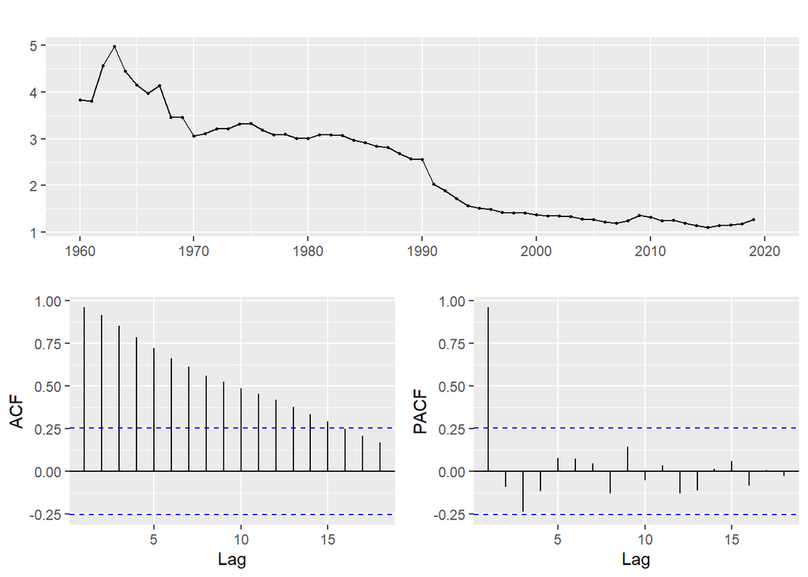

O primeiro gráfico acima mostra uma tendência de queda suave sem sazonalidade e sem médias móveis (MA).

Acima apresentamos também outras maneiras de visualizar a série, que é pela Função de Autocorrelação (ACF) e pela Função de Autocorrelação Parcial (PACF). Reparem que a ACF mostra também que há tendência, pois o decaimento da ACF é bastante lento e não temos nenhum padraõ sazonal, uma vez que não apresenta picos em nenhum dos lags, isto é, não temos nenhum pico em nenhum ano. No que diz respeito ao gráfico da PACF, vemos que ela possui um lag na primeira defasagem ou atraso, enquanto as outras lags possuem um comportamento bem comportado.

Esta visualização sugere para nós que temos um modelo AR1 (1,1,0)

##### 5.2.2 A IDENTIFICAÇAO CONFORME O MODELO AUTOMÁTICO ARIMA

```
## Series: alemanha_TS
## ARIMA(0,1,0) with drift
##
## Coefficients:
##         drift
##       -0.0432
## s.e.   0.0253
##
## sigma^2 estimated as 0.03838:  log likelihood=12.97
## AIC=-21.93   AICc=-21.72   BIC=-17.78
```

Ao contrário de nossa análise, a função automática gerou um modelo diferente: um ARIMA (0,1,0)

#### 5.2.3 Comparando os dois modelos ARIMA

```
## [1] -20.2528
```

```
## [1] -21.93478
```

Utilizando a função AIC para nosso modelo, encontramos o valor -20.2528, enquanto para o modelo automático -21.93478. Comparando, os dois valores vemos que o modelo automático tem uma melhor previsão, pois o valor AIC é menor do que o nosso modelo.

#### 5.2.4 ESTIMAÇÃO VISUAL DO MODELO ARIMA AUTOMÁTICO PARA ALEMANHA (0,1,0)

Uma vez que o modelo automático se mostrou mais adequado, nós o utilizaremos para fins de estimação visual.

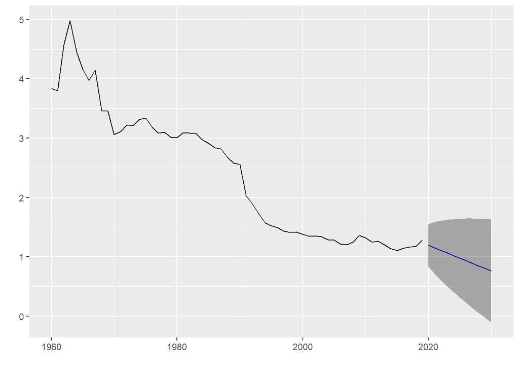

O gráfico de estimação acima, sugere que os gastos militares como percentual do PIB na Alemanha dominuirá nos próximos 10 anos, isto é, até 2030.

##### 5.2.5 TABULAÇÃO DOS GASTOS MILITARES NA ALEMANHA CONFORME O MODELO AUTOMÁTICO ARIMA (0,1,0)

Faremos aqui a previsão tabular dos gastos militares em relação a percentual do PIB para Alemanha nos próximos 10 anos.

```
##      Point Forecast       Lo 80    Hi 80       Lo 95    Hi 95
## 2020      1.1930204  0.83798196 1.548059  0.65003594 1.736005
## 2021      1.1497806  0.71494901 1.584612  0.48476309 1.814798
## 2022      1.1065407  0.60444047 1.608641  0.33864466 1.874437
## 2023      1.0633008  0.50193571 1.624666  0.20476696 1.921835
## 2024      1.0200610  0.40511628 1.635006  0.07958423 1.960538
## 2025      0.9768211  0.31260492 1.641037 -0.03900988 1.992652
## 2026      0.9335812  0.22350427 1.643658 -0.15238777 2.019550
## 2027      0.8903414  0.13719101 1.643492 -0.26150270 2.042185
## 2028      0.8471015  0.05321132 1.640992 -0.36704876 2.061252
## 2029      0.8038616 -0.02877742 1.636501 -0.46954990 2.077273
## 2030      0.7606218 -0.10904136 1.630285 -0.56941320 2.090657
```

Conforme o modelo automático, os gastos miliares em relação ao PIB em 2030 na Alemanha será de menos de 1% do PIB, cerca de 0.76%.

#### 5.2.6 CHECANDO OS RESÍDUOS

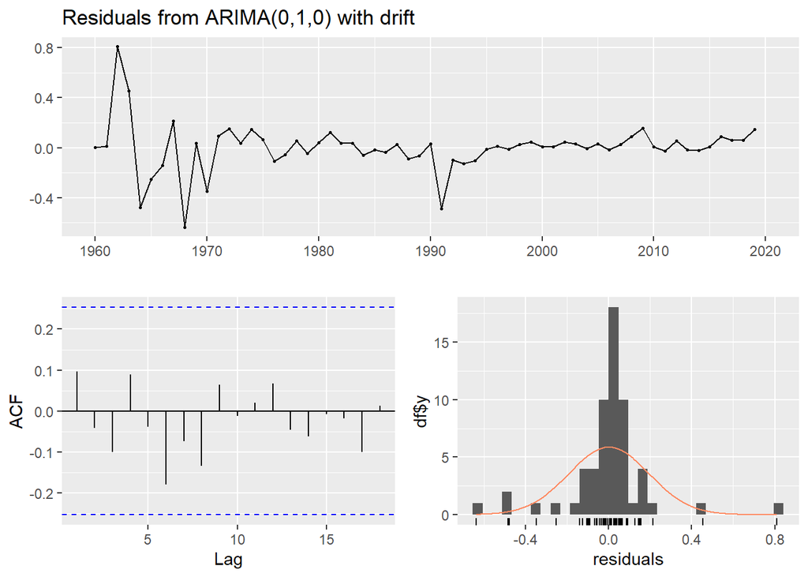

```
##
##  Ljung-Box test
##
## data:  Residuals from ARIMA(0,1,0) with drift
## Q* = 6.1629, df = 9, p-value = 0.7235
##
## Model df: 1.   Total lags used: 10
```

os residuais estão dentro dos limites do gráfico ACF, o que significa que nenhuma informação remanescente nos dados. Podemos prever com segurança com nosso modelo

### 5.3 RÚSSIA

#### 5.3.1 IDENTIFICAÇÃO VISUAL DA SÉRIE TEMPORAL DA RÚSSIA

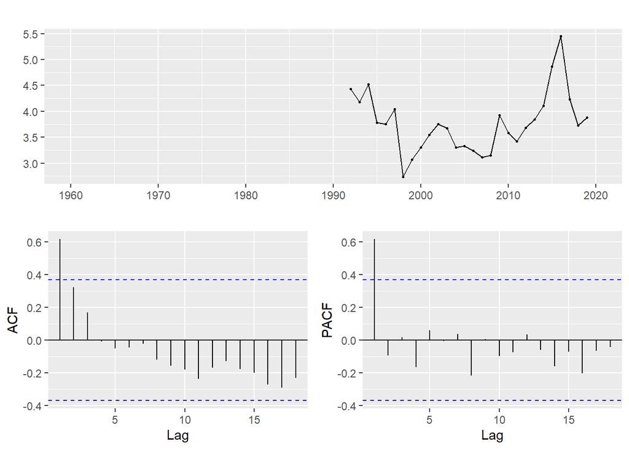

Acima apresentamos também outras maneiras de visualizar a série, que é pela Função de Autocorrelação (ACF) e pela Função de Autocorrelação Parcial (PACF). Reparem que a ACF mostra uma tendência de queda, pois o decaimento da ACF é bastante rápido e não temos nenhum padraõ sazonal, uma vez que não apresenta picos em nenhum dos lags, isto é, não temos nenhum pico em nenhum ano. No que diz respeito ao gráfico da PACF, vemos que ela possui um lag na primeira defasagem ou atraso, enquanto as outras lags possuem um comportamento bem comportado.

Visualmente, podemos concluir que pode ser um ARIMA (1,1,0).

##### 5.3.2 A IDENTIFICAÇAO CONFORME O MODELO AUTOMÁTICO ARIMA

```
## Series: russia_TS
## ARIMA(1,0,0) with non-zero mean
##
## Coefficients:
##          ar1    mean
##       0.6266  3.8141
## s.e.  0.1440  0.2126
##
## sigma^2 estimated as 0.2105:  log likelihood=-17.13
## AIC=40.25   AICc=41.25   BIC=44.25
```

Ao contrário de nossa análise, a função automática gerou um modelo diferente: um ARIMA (1,0,0)

#### 5.3.3 Comparando os dois modelos

```
## [1] 42.13731
```

```
## [1] 40.25128
```

Utilizando a função AIC para nosso modelo, encontramos o valor 42.13731 , enquanto para o modelo automático 40.25128. Comparando, os dois valores vemos que o nosso modelo não expressa tão também a previsibilidade, pois o AIC de nosso modelo é maior do que o do modelo automático.

#### 5.3.4 ESTIMAÇÃO VISUAL DO MODELO ARIMA AUTOMÁTICO PARA RÚSSIA (1,0,0)

Para a estimação automática para os gastos militares da Rússia, utilizaremos a função auto.arima(), que utiliza o algoritimo desenvolvido e publicado por Hyndman e Khandakar (2008) que combina a aplicação de testes de raízes unitarias, minimização do AIC e MLE utilizado o procedimento stepwise.

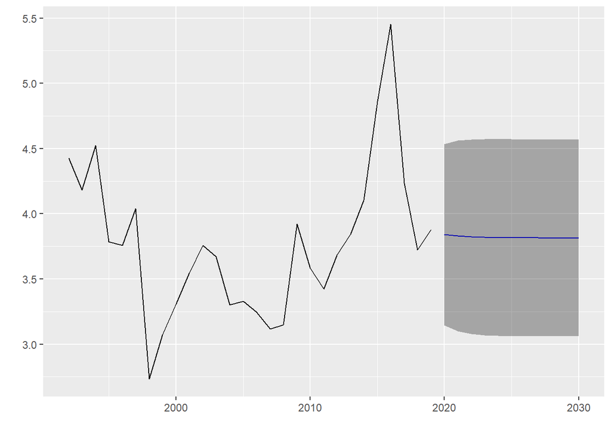

O gráfico de estimação acima, sugere que os gastos militares como percentual do PIB na Rússia se manterá estável nos próximos 10 anos, isto é, até 2030.

#### 5.3.5 TABULAÇÃO DOS GASTOS MILITARES NA RUSSIA CONFORME O MODELO AUTOMÁTICO ARIMA (1,0,0)

```
##      Point Forecast    Lo 80    Hi 80    Lo 95    Hi 95
## 2020       3.839433 3.145572 4.533293 2.778265 4.900601
## 2021       3.829981 3.098722 4.561240 2.711617 4.948345
## 2022       3.824058 3.078628 4.569489 2.684021 4.964096
## 2023       3.820347 3.069425 4.571269 2.671911 4.968783
## 2024       3.818022 3.064954 4.571089 2.666305 4.969739
## 2025       3.816564 3.062657 4.570472 2.663562 4.969567
## 2026       3.815651 3.061414 4.569889 2.662144 4.969158
## 2027       3.815079 3.060712 4.569446 2.661374 4.968784
## 2028       3.814721 3.060303 4.569139 2.660938 4.968503
## 2029       3.814496 3.060058 4.568934 2.660683 4.968309
## 2030       3.814355 3.059910 4.568801 2.660530 4.968180
```

Vemos que o modelo automático também gerou um valor bem alto para os gastos militares em relação ao percentual do PIB, cerca de 3.81%.

#### 5.3.6 CHECANDO OS RESÍDUOS

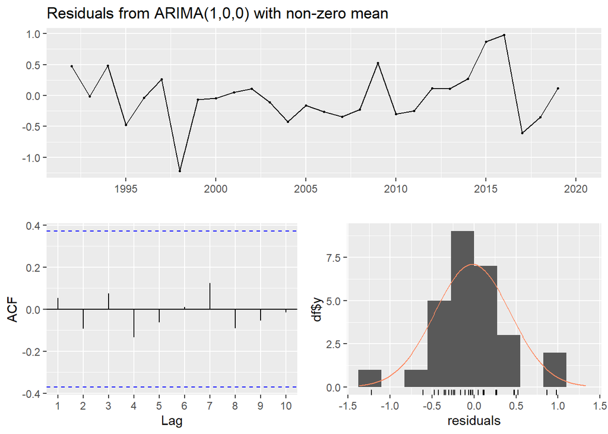

```
##
##  Ljung-Box test
##
## data:  Residuals from ARIMA(1,0,0) with non-zero mean
## Q* = 1.3244, df = 4, p-value = 0.8572
##
## Model df: 2.   Total lags used: 6
```

os residuais estão dentro dos limites do gráfico ACF, o que significa que nenhuma informação remanescente nos dados. Podemos prever com segurança com nosso modelo

### 5.4 INGLATERRA

#### 5.4.1 IDENTIFICAÇÃO VISUAL DA SÉRIE TEMPORAL DA INGLATERRA

O Gráfico abaixo mostra o total de gastos militares em relação ao PIB na Inglaterra entre os anos de 1960 até 2019 e as autocorrelações ACF e PACF

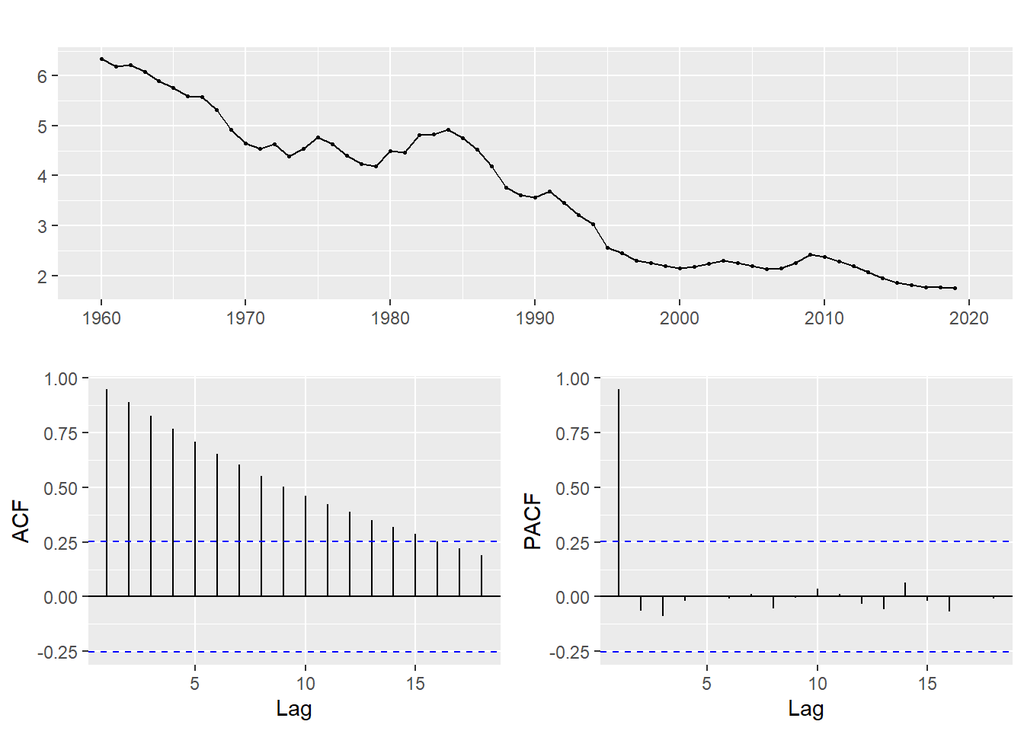

O primeiro gráfico acima parece sugerir que há uma queda suave nos gastos militares em relação ao PIB.

Acima apresentamos também Uma outra maneira de visualizar esta série, que é pela Função de Autocorrelação (ACF).Reparem que ele mostra tendência de queda suave ao longo do tempo até o lag 16.Já a PACF possui uma lag inicial.

Visualmente, podemos concluir que pode ser um ARIMA (1,1,0).

#### 5.4.2 IDENTIFICAÇÃO DO MODELO ARIMA AUTOMÁTICO PARA INGLATERRA

```
## Series: inglaterra_TS
## ARIMA(1,1,0) with drift
##
## Coefficients:
##          ar1    drift
##       0.3840  -0.0782
## s.e.  0.1189   0.0306
##
## sigma^2 estimated as 0.02209:  log likelihood=29.69
## AIC=-53.38   AICc=-52.94   BIC=-47.14
```

#### 5.4.3 Comparando os dois modelos

```
## [1] -50.25983
```

```
## [1] -53.37507
```

Utilizando a função AIC para nosso modelo, encontramos o valor -50.25983 , enquanto para o modelo automático -53.37507 . Comparando, os dois valores vemos que o modelo automático se sai melhor que o nosso, uma vez que, o AIC do modelo automático é menor do que o nosso.

#### 5.4.4 ESTIMAÇÃO VISUAL DO MODELO ARIMA AUTOMÁTICO PARA INGLATERRA (1,1,0)

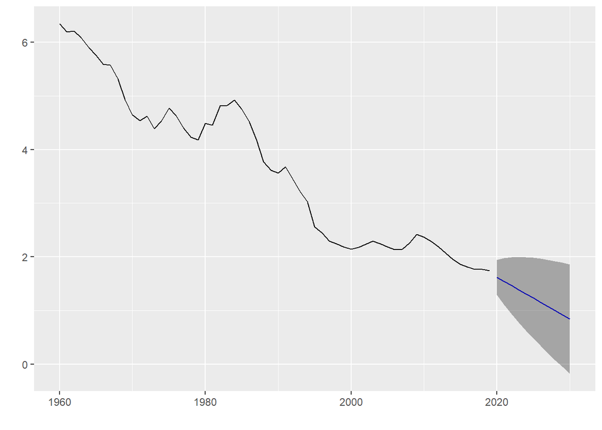

O gráfico do modelo automático mostra que os gastos militares tendem a diminuir ao longo do tempo, pelo menos, nos próximos 10 anos, isto é, até 2030.

#### 5.4.5 TABULAÇÃO DOS GASTOS MILITARES NA INGLATERRA CONFORME O MODELO AUTOMÁTICO ARIMA (1,1,0)

Faremos aqui a previsão tabular dos gastos militares em relação a percentual do PIB para Inglaterra nos próximos 10 anos

```
##      Point Forecast       Lo 80    Hi 80       Lo 95    Hi 95
## 2020      1.6166814  1.29142022 1.941943  1.11923734 2.114125
## 2021      1.5416670  1.10474398 1.978590  0.87345089 2.209883
## 2022      1.4647134  0.93328309 1.996144  0.65196086 2.277466
## 2023      1.3870152  0.77345367 2.000577  0.44865382 2.325377
## 2024      1.3090310  0.62239047 1.995672  0.25890492 2.359157
## 2025      1.2309370  0.47802959 1.983844  0.07946447 2.382410
## 2026      1.1528009  0.33891582 1.966686 -0.09192891 2.397531
## 2027      1.0746486  0.20401437 1.945283 -0.25687152 2.406169
## 2028      0.9964900  0.07257430 1.920406 -0.41651714 2.409497
## 2029      0.9183291 -0.05596288 1.892621 -0.57172189 2.408380
## 2030      0.8401672 -0.18202285 1.862357 -0.72313759 2.403472
```

Vemos que o modelo automático gerou um valor menor que 1% para os gastos militares em relação ao percentual do PIB, cerca de 0.8401672

#### 5.4.6 CHECANDO OS RESÍDUOS

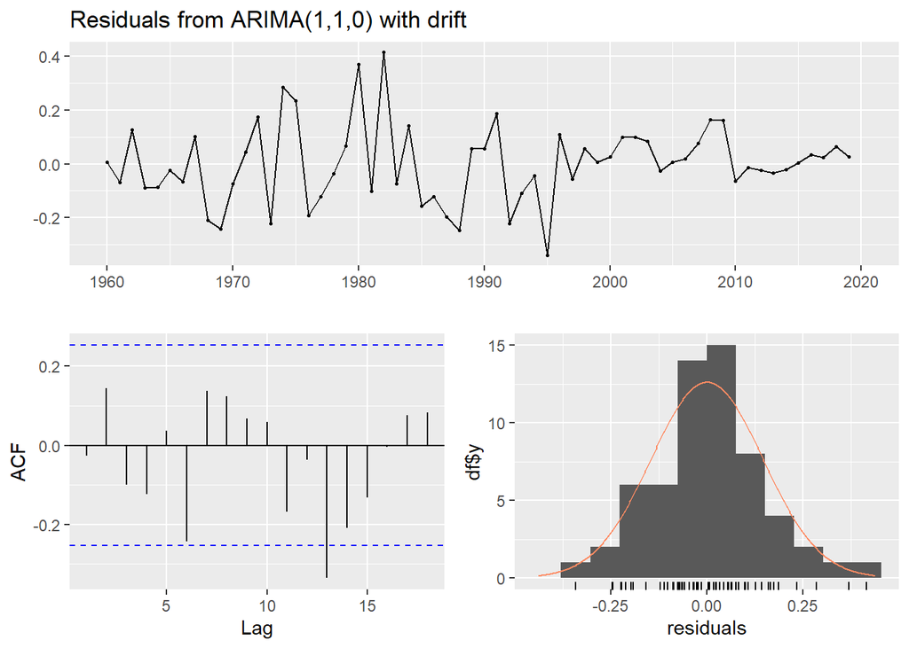

```
##
##  Ljung-Box test
##
## data:  Residuals from ARIMA(1,1,0) with drift
## Q* = 10.24, df = 8, p-value = 0.2486
##
## Model df: 2.   Total lags used: 10
```

### 5.5 USA

#### 5.5.1 IDENTIFICAÇÃO VISUAL DA SÉRIE TEMPORAL DOS USA

O Gráfico abaixo mostra o total de gastos militares em relação ao PIB nos USA entre os anos de 1960 até 2019 e as autocorrelações ACF e PACF

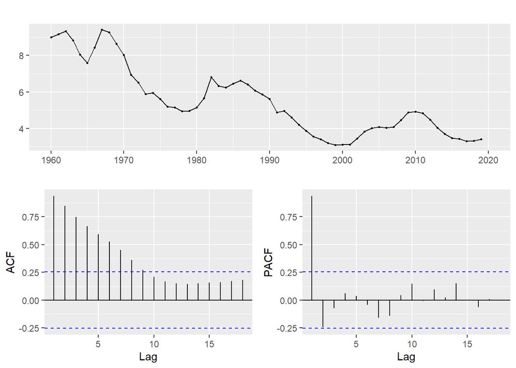

O primeiro gráfico acima parece sugerir que é um modelo cíclico de difícil previsão.

Acima apresentamos também Uma outra maneira de visualizar esta série, que é pela Função de Autocorrelação (ACF). Reparem que ele mostra tendência de queda, porém o decaimento da ACF é suave sem nenhum padrão sazonal, uma vez que não apresenta picos em nenhum. dos lags. Já a PACF possui uma lag inicial.

Visualmente, podemos concluir que pode ser um ARIMA (1,1,0).

#### 5.5.2 IDENTIFICAÇÃO DO MODELO ARIMA AUTOMÁTICO PARA USA

```
## Series: usa_TS
## ARIMA(1,1,0)
##
## Coefficients:
##          ar1
##       0.4528
## s.e.  0.1143
##
## sigma^2 estimated as 0.1388:  log likelihood=-25.08
## AIC=54.15   AICc=54.37   BIC=58.31
```

A função automática gerou o mesmo modelo do nosso: um ARIMA (1,1,0)

## 5.5.3 COMPARANDO OS DOIS MODELOS

```
## [1] 54.15435
```

```
## [1] 54.15435
```

```
## [1] 54.15435
```

```
## [1] 54.15435
```

Utilizando a função AIC para nosso modelo, encontramos o valor 54.15435 , enquanto para o modelo automático 54.15435. Comparando, os dois valores vemos que o nosso modelo equivale ao modelo automático.

#### 5.5.4 ESTIMAÇÃO VISUAL DO MODELO ARIMA AUTOMÁTICO PARA USA (1,1,0)

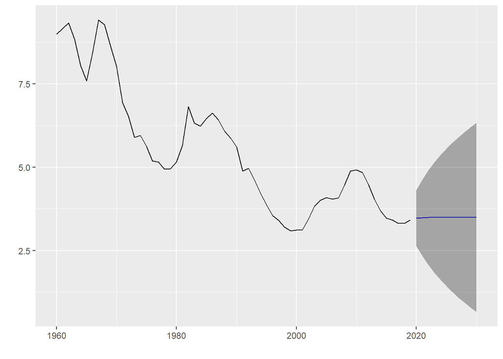

O gráfico do modelo automático mostra que os gastos militares tendem a se estabilizar ao longo do tempo, pelo menos, nos próximos 10 anos, isto é, até 2030.

##### 5.5.5 TABULAÇÃO DOS GASTOS MILITARES NOS USA CONFORME O MODELO AUTOMÁTICO ARIMA (1,1,0)

Faremos aqui a previsão tabular dos gastos militares em relação a percentual do PIB para USA nos próximos 10 anos

```
##      Point Forecast     Lo 80    Hi 80       Lo 95    Hi 95
## 2020       3.476821 2.6346914 4.318950  2.18889521 4.764746
## 2021       3.485811 2.3300622 4.641561  1.71824553 5.253377
## 2022       3.489882 2.0635371 4.916227  1.30847561 5.671289
## 2023       3.491725 1.8282606 5.155190  0.94767558 6.035775
## 2024       3.492560 1.6176182 5.367502  0.62508405 6.360036
## 2025       3.492938 1.4263386 5.559537  0.33234716 6.653528
## 2026       3.493109 1.2504544 5.735763  0.06326491 6.922953
## 2027       3.493186 1.0870201 5.899352 -0.18672726 7.173100
## 2028       3.493221 0.9338390 6.052604 -0.42101623 7.407459
## 2029       3.493237 0.7892508 6.197224 -0.64215314 7.628628
## 2030       3.493244 0.6519800 6.334509 -0.85209454 7.838583
```

Vemos que o modelo automático também gerou um valor bem alto para os gastos militares em relação ao percentual do PIB, cerca de 3.49%

#### 5.5.6 CHECANDO OS RESÍDUOS

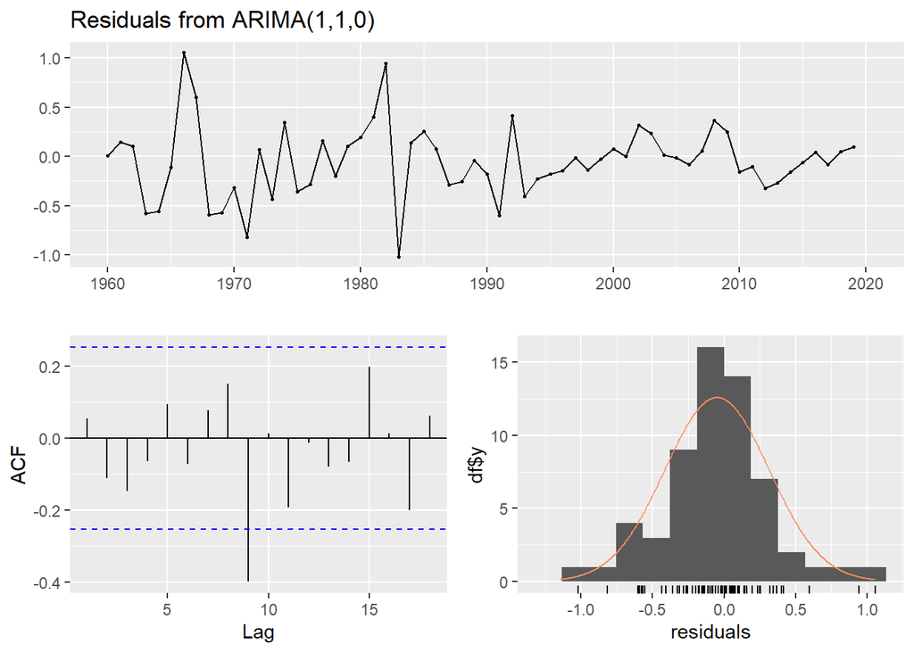

```
##
##  Ljung-Box test
##
## data:  Residuals from ARIMA(1,1,0)
## Q* = 17.303, df = 9, p-value = 0.04418
##
## Model df: 1.   Total lags used: 10
```

### 5.6 CHINA

#### 5.6.1 IDENTIFICAÇÃO VISUAL DO MODELO

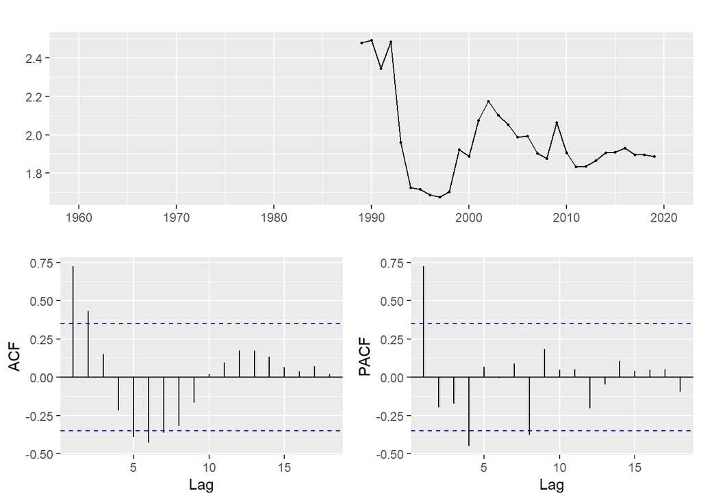

O primeiro gráfico acima parece sugerir que é um modelo cíclico de difícil previsão.

Visualmente, podemos concluir que pode ser um ARIMA (1,1,0).

#### 5.6.2 IDENTIFICAÇÃO DO MODELO ARIMA AUTOMÁTICO PARA CHINA

```
## Series: china_TS
## ARIMA(1,0,0) with non-zero mean
##
## Coefficients:
##          ar1    mean
##       0.8411  2.0273
## s.e.  0.1040  0.1322
##
## sigma^2 estimated as 0.01852:  log likelihood=18.26
## AIC=-30.52   AICc=-29.63   BIC=-26.22
```

#### 5.6.3 COMPARANDO OS DOIS MODELOS

```
## [1] -30.58037
```

```
## [1] -30.58037
```

```
## [1] -30.51802
```

```
## [1] -30.51802
```

#### 5.6.4 ESTIMAÇÃO VISUAL DO NOSSO MODELO PARA CHINA (1,1,0)

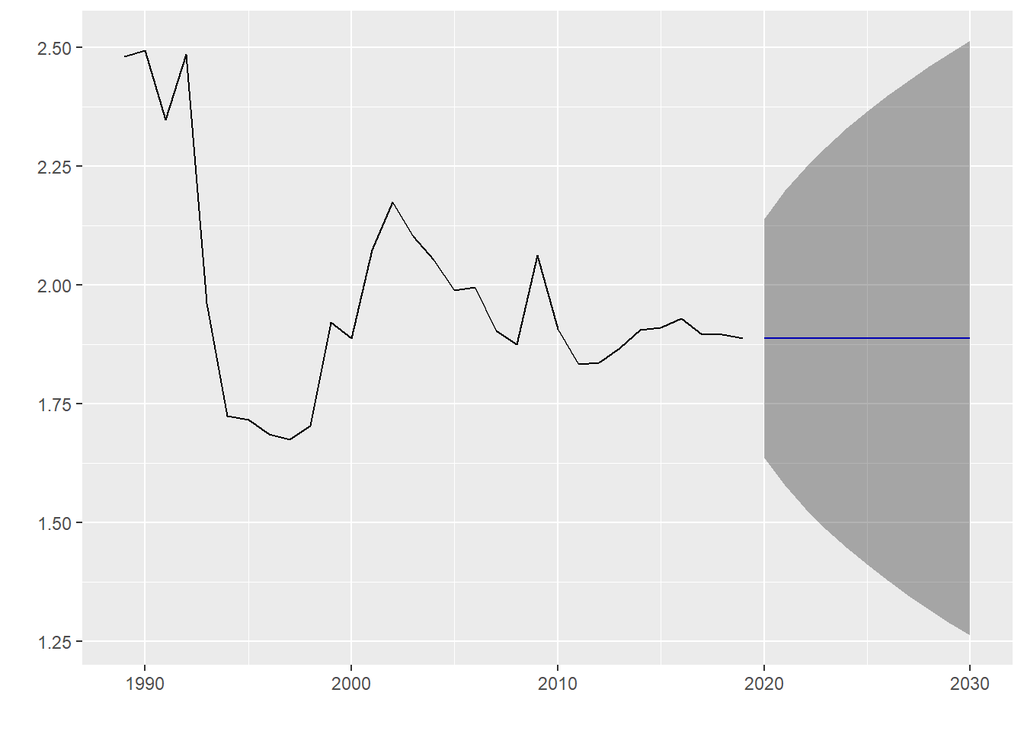

#### 5.6.5 TABULAÇÃO DOS GASTOS MILITARES DA CHINA CONFORME O NOSSO MODELO ARIMA (1,1,0)

```
##      Point Forecast    Lo 80    Hi 80     Lo 95    Hi 95
## 2020       1.888292 1.637118 2.139465 1.5041550 2.272428
## 2021       1.888291 1.578610 2.197973 1.4146740 2.361909
## 2022       1.888291 1.529514 2.247068 1.3395894 2.436993
## 2023       1.888291 1.486372 2.290211 1.2736088 2.502974
## 2024       1.888291 1.447431 2.329151 1.2140544 2.562528
## 2025       1.888291 1.411662 2.364921 1.1593495 2.617233
## 2026       1.888291 1.378395 2.398187 1.1084727 2.668110
## 2027       1.888291 1.347170 2.429412 1.0607179 2.715865
## 2028       1.888291 1.317651 2.458932 1.0155722 2.761010
## 2029       1.888291 1.289585 2.486997 0.9726498 2.803933
## 2030       1.888291 1.262778 2.513805 0.9316513 2.844931
```

Vemos que o nosso modelo também gerou uma previsão de gastos militares em relação ao percentual do PIB em 2030 de 1.88%.

#### 5.2.6 CHECANDO OS RESÍDUOS

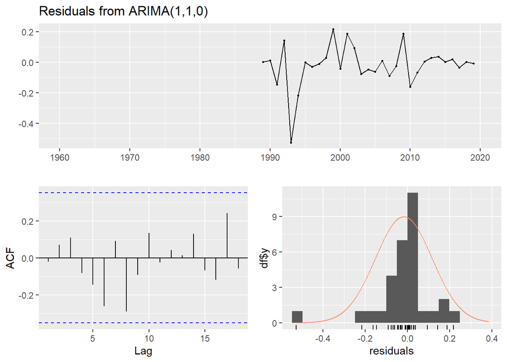

```
##
##  Ljung-Box test
##
## data:  Residuals from ARIMA(1,1,0)
## Q* = 9.9067, df = 9, p-value = 0.3581
##
## Model df: 1.   Total lags used: 10
```

os residuais estão dentro dos limites do gráfico ACF, o que significa que nenhuma informação remanescente nos dados. Podemos prever com segurança com nosso modelo

### 5.7 BRASIL

#### 5.7.1 IDENTIFICAÇÃO VISUAL DO MODELO

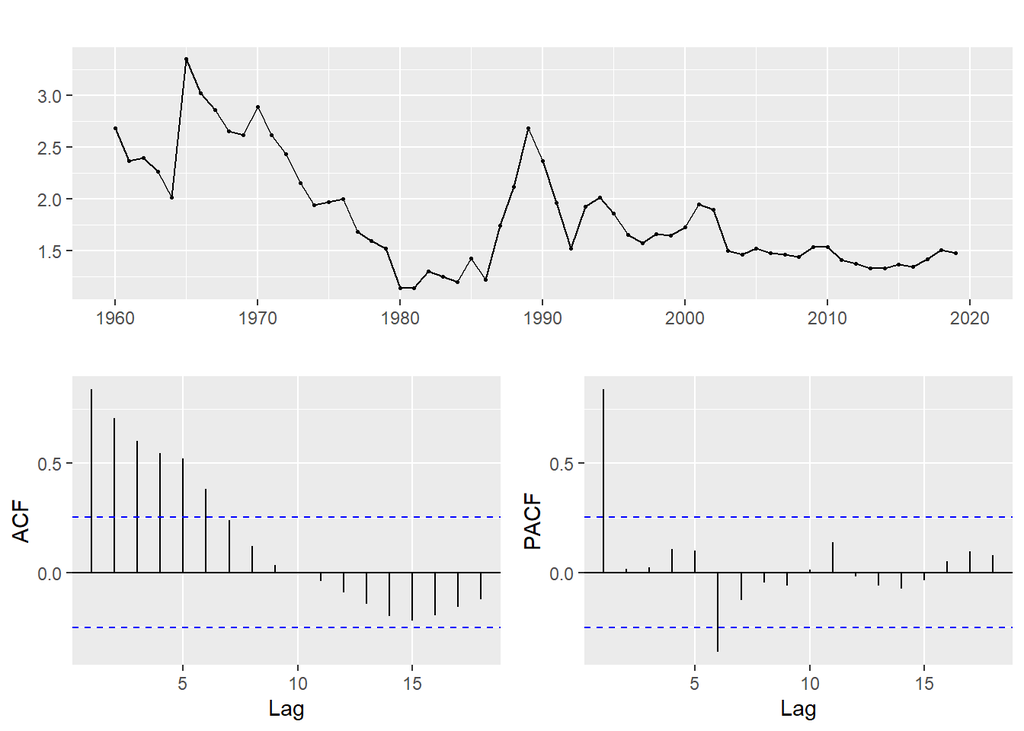

O primeiro gráfico acima parece sugerir que é um modelo cíclico de difícil previsão.

Acima apresentamos também Uma outra maneira de visualizar esta série, que é pela Função de Autocorrelação (ACF). Reparem que ele mostra tendência de queda, porém o decaimento da ACF é rápido sem nenhum padrão sazonal, uma vez que não apresenta picos em nenhum. dos lags, não temos nenhum pico em nenhum dos anos.

Já a PACF possui uma lag inicial. E as outras lag possuem um padrão bem comportado, com a exceção da lag 6 que pdemos descatar, sem maiores prejuízos.

Assim, visualmente, podemos concluir que pode ser um ARIMA (1,0,0).

```
## Series: brasil_TS
## ARIMA(0,1,0)
##
## sigma^2 estimated as 0.07726:  log likelihood=-8.18
## AIC=18.36   AICc=18.43   BIC=20.44
```

Diferentemente de nossa sugestão para o modelo, o ARIMA automático gerou o modelo (0,1,0)

#### 5.7.3 COMPARANDO OS DOIS MODELOS

```
## [1] 20.0835
```

```
## [1] 18.36325
```

Comparando os dois modelos, vemos que o AIC do nosso modelo é igual a 20.0835 e o AIC do modelo automático é de 18.36325. Logo, o melhor modelo é o automático, pois tem o menor AIC.

#### 5.7.4 IDENTIFICAÇÃO DO MODELO ARIMA AUTOMÁTICO PARA o BRASIL (0,1,0)

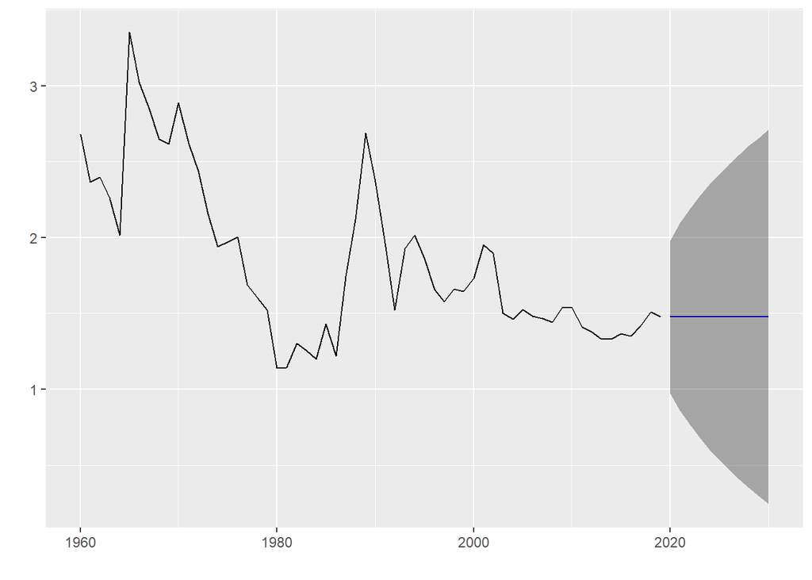

O gráfico do modelo automático mostra que os gastos militares tendem a se estabilizar ao longo do tempo, pelo menos, nos próximos 10 anos, isto é, até 2030.

#### 5.7.5 TABULAÇÃO DOS GASTOS MILITARES DO BRASIL CONFORME O MODELO ARIMA AUTOMÁTICO (0.1.0)

```
##      Point Forecast     Lo 80    Hi 80       Lo 95    Hi 95
## 2020       1.476022 0.9722444 1.979799  0.70556080 2.246482
## 2021       1.476022 0.8590230 2.093020  0.53240367 2.419640
## 2022       1.476022 0.7635730 2.188470  0.38642547 2.565618
## 2023       1.476022 0.6794798 2.272563  0.25781609 2.694227
## 2024       1.476022 0.6034538 2.348589  0.14154432 2.810499
## 2025       1.476022 0.5335407 2.418503  0.03462139 2.917422
## 2026       1.476022 0.4684671 2.483576 -0.06490004 3.016943
## 2027       1.476022 0.4073487 2.544695 -0.15837262 3.110416
## 2028       1.476022 0.3495414 2.602502 -0.24678117 3.198824
## 2029       1.476022 0.2945592 2.657484 -0.33086920 3.282912
## 2030       1.476022 0.2420244 2.710019 -0.41121429 3.363258
```

#### 5.2.6 CHECANDO OS RESÍDUOS

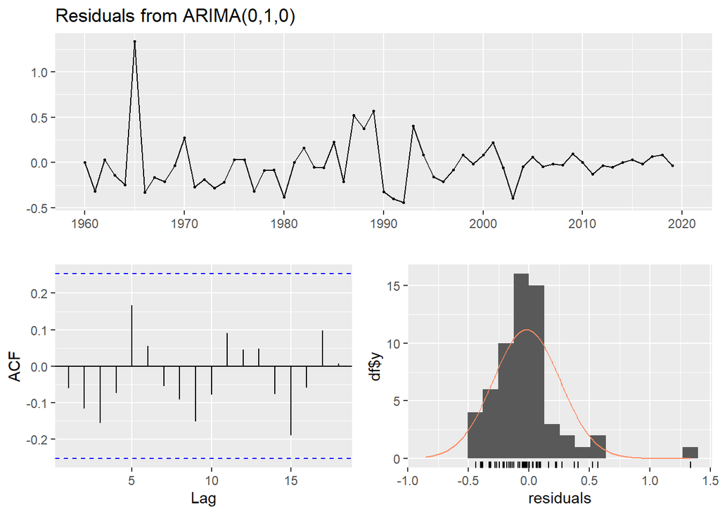

```
##
##  Ljung-Box test
##
## data:  Residuals from ARIMA(0,1,0)
## Q* = 8.0849, df = 10, p-value = 0.6205
##
## Model df: 0.   Total lags used: 10
```

os residuais estão dentro dos limites do gráfico ACF, o que significa que nenhuma informação remanescente nos dados. Podemos prever com segurança com nosso modelo

# CONCLUSÃO

Deste modo, temos um grupo de países que possui um gasto levadíssimo do PIB: Rússia e USA. Um outro grupo de países com tendência de gastar menos de 1% do PIB no setor militar. A China e Brasil parece se situar entre estes dois grupos. O primeiro gastando 1.88% do PIB e o segundo 1.47% do PIB.

Uma vez que o Brasil não entra em guerra desde 1945 e não temos rivalidades com países vizinhos de nenhu tipo, o que justificaria um gastos acima de 1% do PIB? Para nós tais gastos não se justificam. Resumdmente: estamos gastando mais do que o necessário com as forças armadas. Temos mais ineficiência alocativa do que benefícios pátricos com os gastos militares